# RichTextLabel

# RichTextLabel shows fancy text

The `RichTextLabel` node lets you show formatted and animated text to the player.

It offers an optional scrollbar to display lots of text, making it great for chat logs.

In this guide, you will learn:

- How to create a `RichTextLabel` and set its text.
- How to use built-in BBCode to format and animate your text.
- How to use scrollbars in long chat logs.
- How to make custom tooltips for showing extra information.
- How to create custom text effects and text animations.

Contents:

- Setting up a RichTextLabel
- The RichTextLabel’s key features
  - Displaying formatted text
  - Built-in scrolling
- How to use a RichTextLabel in practice
  - Formatting text with BBCode
  - Creating a scrolling chat log
  - Create custom tooltips
  - Designing custom text effects
- Your questions
  - How can I center a RichTextLabel?
  - How can I find more BBCode options
  - How can I animate text display with a RichTextLabel?
  - How do I order Bb Code tags?
  - How do I create hyperlinks with RichTextLabel?

## Setting up a RichTextLabel

1. Add the `RichTextLabel` to your scene.
2. Set custom fonts on the `RichTextLabel` or in a theme for formatting like bold and italic text.
3. Either set the text property or turn on *Bb Code -> Enabled* and set *Bb Code -> Text* to the words you want to show.
4. Position your `RichTextLabel` and use the *Layout* menu or set its *Rect -> Size* to control its anchors and bounding box.

## The RichTextLabel’s key features

### Displaying formatted text

A `RichTextLabel` has two text properties:

- The *Text* property displays unformatted plain text.
- The *Bb Code -> Text* allows you to display formatted text with BBCode. BBCode is a lightweight markup language with plenty of public information in their [Wikipedia entry](https://en.wikipedia.org/wiki/BBCode).

To use the BBCode text, you need to turn on the *Bb Code -> Enabled* property.

To use the bold, italic, mono, and bold italic BBCode tags, you will need to add corresponding fonts.

It’s best to set up your fonts and styling options through a theme resource to reuse the styling on other `RichTextLabel` nodes. For more information, see our video introducing themes:

[figure not shown]

To set up the fonts in your theme, add the `RichTextLabel` class items to your `Theme` resource.

To do so, open your resource and in the `Theme` bottom panel:

1. Click *Edit Theme* in the top-right.
2. Click *Add Class Item* and select the three dots on the right.

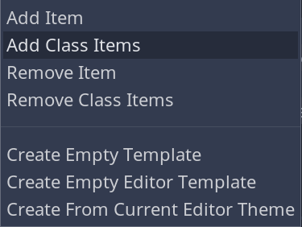

3. In here, you can choose `RichTextLabel` and select *Add All*.

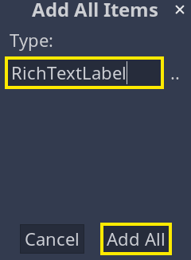

This will add the `RichTextLabel` to your theme drop-down in the *Inspector*.

To set the five font options, in the *Inspector*, navigate to *Theme -> Rich Text Label -> Font*.

Then for each format you want, add a `DynamicFont`. In this font resource, you can add your `ttf` or `otf` font file in *Font -> Font Data*. It’s up to you to add the right font file (bold, italic) to the right font slot.

### Built-in scrolling

`RichTextLabel` nodes are scrollable by default: when you type more text than the text box can contain, a scroll bar appears on the right.

[figure not shown]

To achieve the same result with a `Label`, you would need a separate `ScrollContainer` and glue code.

You can remove the `RichTextLabel`’s scroll bar by disabling the *Scroll Active* property.

## How to use a RichTextLabel in practice

### Formatting text with BBCode

BBCode lets you format text with tags, so you will need them if you want your text centered, bold, italic, and much more.

For the markup to work, you first want to turn on *Bb Code -> Enabled*.

Then, enter your text with BBCode tags inside the *Bb Code -> Text* box.

Here are some tags you can use:

- Surrounding text with `[b][/b]` will display it as **bold**. You can use that to emphasize locations and quest goals in a game.
- Surrounding text with `[i][/i]` will display it as *italics*. We typically use that to *emphasize* a word and make it stand out, although less than with bold.
- You can color text with the `[color=red][/color]` tags. You need to write the color’s name or a hexadecimal value after the `=` sign. We typically use that to differentiate character names in online game chats.

Here’s an example of color BBCode.

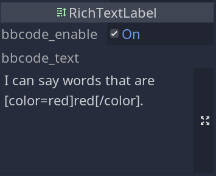

And the result in-game.

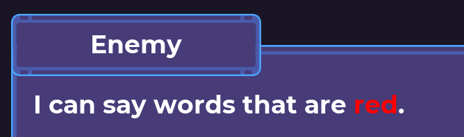

You can find a few more examples in the code sample below. The built-in `shake` effect is especially noteworthy: it animates the text and makes it shake.

```
## A list of strings with BBCode markup.
var sentences := [
    # The Color tag lets you pass in a default or specific hex color the text should be.
    "I can say words that are [color=red]red[/color].",
    "I can [u]underline words[/u] that I think are important.",
    # The [s] tag strikes through the text.
    "[s]Scratch that I didn't want to say any of this.[/s]",
    # Shake is a built-in shaking animation with a given rate and magnitude (level) in pixels
    "[shake rate=5 level=10]I don't feel so good.[/shake]",
    #...
]

# ...
func speak() -> void:
    # We can set the BBCode text to show a random new sentence by shuffling the list of sentences until the first word changes.
    while _rich_text_label.bbcode_text == sentences.front():
        sentences.shuffle()
    _rich_text_label.bbcode_text = sentences.front()
```

### Creating a scrolling chat log

When making a multiplayer game, you often want to offer a chat window. The chat needs a field where the player can type and submit text and an area where they can read other players’ messages.

[figure not shown]

For the input field, you can use a `LineEdit` node. And for the chat log, `RichTextLabel` is a perfect fit.

When creating a log of chat messages, being scrollable is important to check old messages. A `RichTextLabel` is scrollable by default.

If you turn on the *Scroll Following* property, the log will scroll to the end immediately when you add new lines.

But note that when you store text a user enters, it is important to consider input validation. Any user could enter BBCode tags into your `RichTextLabel` and break your formatting.

#### Sanitizing input text

There are several ways to sanitize player text. The simplest is to use the `String.replace()` function to remove square brackets before adding the text to the chatbox.

```
# Reference to the input field in which the player types text.
onready var _line_edit: LineEdit = $NinePatchRect/VBoxContainer/HBoxContainer/LineEdit
# Reference to the RichTextLabel displaying the chat log.
onready var _chat_log: RichTextLabel = $NinePatchRect/VBoxContainer/ChatLog

func send_chat_message() -> void:
    if _line_edit.text.length() == 0:
        return
    var text: String = _line_edit.text.replace("[", "{").replace("]", "}")
    # We'll see this function below.
    add_reply(text, player_name)
    _line_edit.text = ""
```

A more robust alternative is to use regular expressions, abbreviated as “regex.” This is a pattern-matching language that searches for and replaces text.

Covering regular expressions is beyond the scope of this guide, but note that Godot uses a syntax based on the Perl programming language.

Here’s an example that removes BBCode syntax from a string.

```
var _regex_bbcode := RegEx.new()

func _ready() -> void:
    # We need to compile regular expressions in Godot.
    # Notice the double backslashes: you need to escape every backslash in strings in GDScript.
    _regex_bbcode.compile('\\[\\/?[\\w\\s=]+\\]')
    # You can then use the RegEx's `sub()` method to replace text that matches it.
    # The following prints "I don't feel so good."
    print(_regex_bbcode.sub("[shake rate=5 level=10]I don't feel so good.[/shake]", "", true))
```

To learn more about using Godot’s `ReGex` object, head to the [ReGex class reference](https://docs.godotengine.org/en/stable/classes/class_regex.html).

You can test and practice creating Perl-like regular expressions interactively with a tool like [regex 101](https://regex101.com/).

#### Formatting the chat log

You can use [formatted strings](https://docs.godotengine.org/en/stable/getting_started/scripting/gdscript/gdscript_format_string.html) to print the player’s name, assign them some color, and print their message to the chat log.

Below, we define a template with placeholder marks we can dynamically replace with other values.

[figure not shown]

```
# "%s" is a placeholder to replace with some text or value.
# The "\n" at the end represents a line return.
const REPLY_TEMPLATE := "[color=#%s]%s[/color]: %s\n"
# This dictionary maps player names to specific colors we use in the chat.
const PLAYER_COLORS := {
    "Arthur": Color.mediumspringgreen,
    "Ford": Color.hotpink,
    "Trillian": Color.royalblue,
    "Marvin": Color.darkorange,
}

func add_reply(text: String, sender_name: String) -> void:
    # We get the player's color from the dictionary.
    var color: Color = PLAYER_COLORS[sender_name]
    # Combine the player's name, color and message with the REPLY_TEMPLATE.
    _chat_log.bbcode_text += REPLY_TEMPLATE % [color.to_html(false), sender_name, text]
    #...
```

#### Limiting the log’s size

It’s best not to waste space storing an infinity of chat messages. You can use a function to delete older messages as the log becomes full.

```
## The number of messages we display in the chat log.
const HISTORY_LENGTH := 9

func add_reply(text: String, sender_name: String) -> void:
    #...
    # A \n newline separates each message, so we can loop while our text has too many lines.
    while _chat_log.bbcode_text.count("\n") > HISTORY_LENGTH:
        # Find the position in characters of the first new line and remove everything to the left of it.
        var newline_index: int = _chat_log.bbcode_text.find("\n") + 1
        _chat_log.bbcode_text = _chat_log.bbcode_text.right(newline_index)
```

### Create custom tooltips

Tooltips are a great way to show extra information and definitions in your text, like a glossary. These are very easy to make with `RichTextLabel`.

Tooltips are ideal for explaining lore and rules in your game wherever they appear.

[figure not shown]

We can use a dictionary to save our words as keys and their definitions as values.

```
# A dictionary of keywords and their definitions.
var glossary := {
    "space": "Space is big. You just won't believe how vastly, hugely, mind-bogglingly big it is.",
    "ship": "Is there any tea on this spaceship?",
    #...
}
```

The URL BBCode (`[url=...][/url]`) is a meta tag. You can use meta tags on words to emit a `meta_hover_started` signal when hovered over. You can then look the words up in the glossary dictionary for their definition.

The URL meta tag emits string data and is the only meta tag you can add through the *Inspector*.

[figure not shown]

You can add tags via code. This process uses push methods to open tags and pop methods to close the last opened tag.

This is the best way to create a meta tag as you can pass in non-string data to return on a hover or click.

The `push_meta()` function takes the variable you want to emit as a parameter and creates a meta tag. Then add the text within the tag using `add_text()`. Finally, `pop()` to close the tag.

Unlike a URL tag, `push_meta()` can emit any variable, including colors, nodes, and arrays.

Note: you cannot mix pushing tags with setting the value of `bbcode_text` as pushed tags will be lost.

If you want both, add the text with the `append_bbcode()` function, and your pushed tags will not be affected.

```
_rich_text_label.push_meta(Color.firebrick)
_rich_text_label.add_text("This emits a color on hover.")
_rich_text_label.pop()
```

The *Meta Underlined* property lets us underline our meta tags if enabled.

You can use the dictionary to surround keywords with meta tags in code.

```
# Loop over each keyword in our glossary
for keyword in glossary.keys():
        # Replace instances of the keyword in our text with the keyword
        # surrounded by a meta [url] tag so we can detect when it is
        # hovered over.
        label.bbcode_text = label.bbcode_text.replace(
            keyword, "[color=#ff6666][url]%s[/url][/color]" % keyword
        )
```

Now you can connect the `meta_hover_started` signal from the `RichTextLabel` to our script.

```
# Meta holds text of the meta tag that you hovered over.
func _on_RichTextLabel_meta_hover_started(meta) -> void:
    # Use the meta key to get its definition from our glossary.
    _tooltip_display.set_text(meta, glossary[meta])
    _tooltip_display.is_active = true

func _on_RichTextLabel_meta_hover_ended(meta) -> void:
    _tooltip_display.is_active = false
```

The tooltip should become visible and move to the mouse whenever you set `is_active` to true.

[figure not shown]

```
var is_active := false setget set_is_active
# ...
func set_is_active(value: bool):
    is_active = value
    # Only run our _process function when the tooltip is active.
    set_process(is_active)

    if is_active:
        # Immediately become visible when active.
        modulate = Color.white
        _tween.stop_all()
    else:
        # Animate fading out when no longer active.
        _tween.interpolate_property(self, "modulate", modulate, Color.transparent, 0.2)
        _tween.start()
```

In the `_process()` function, we want to set the tooltip’s position to the mouse’s location. We subtract its offset from the position so it doesn’t cover the mouse.

```
func _process(delta: float) -> void:
    rect_global_position = get_global_mouse_position() - rect_pivot_offset
    # Clamp ensures our tooltip doesn't go off the screen when the mouse is too near the left or right edge.
    rect_global_position.x = clamp(rect_global_position.x, 0, 1920 - rect_size.x)
```

If your text reaches the top and bottom of your screen, consider adding a clamp on the y axis as well.

### Designing custom text effects

You can write your own custom text effects and add them to rich text labels for unique animations. For example, you can censor specific words, make text flash a specific color, and scramble letters.

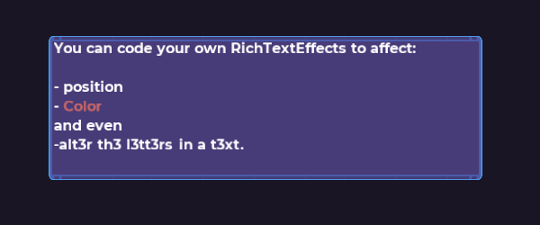

There is no other way to animate individual characters in text, so it can be a very useful tool.

To define an effect, create a new script in the *FileSystem* dock and make it extend `RichTextEffect`.

Give the script a meaningful class name to access its label and define a `bbcode` property. It should be a string, the name you need to put in a BBCode tag to have this effect applied.

```
tool
extends RichTextEffect
class_name RichTextHover

var bbcode := "hover"
```

Define your `_process_custom_fx()` function. Godot will call that function every frame to play your animation.

```
func _process_custom_fx(char_fx: CharFXTransform):
    # This obtains a speed parameter that a user could also include in their tag.
    var speed: float = char_fx.env.get("speed", 5.0)
    # Set the offset of all the characters to follow a sine wave.
    var offset := Vector2(0, sin(char_fx.elapsed_time * speed))
    char_fx.offset = offset
    # Returning true tells the script it can continue and apply the effect to the next letter.
    return true
```

The `char_fx` argument is a `CharFXTransform` class. This class has useful properties you can animate, including `offset`, `color`, and `character`. More information is available on the [CharFXTransform reference page](https://docs.godotengine.org/en/stable/classes/class_charfxtransform.html).

You can get a character’s position in the string with the `char_fx.absolute_index` variable.

`RichTextLabel` stores custom effects in an array. Increase the size by one for each custom effect you want to add.

This will create a drop-down box where you can add your custom effect by its class name. In our case, this is *RichTextHover*.

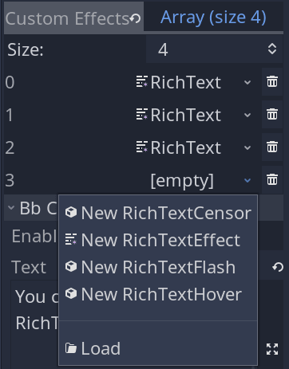

Enable *BBCodes* and add some text surrounded with tags named for the BBCode variable you defined in the script.

## Your questions

### How can I center a RichTextLabel?

Unlike `Label`, the `RichTextLabel` doesn’t have an `align` or `valign` property.

With a `RichTextLabel`, you can use BBCode tags for horizontal alignment. Left by default, with the `[center]` and `[right]` options.

Unfortunately, there is no easy way to align vertically at present. To achieve vertical alignment, you can use anchors to align to the top and bottom, or you can use a center container to center it.

### How can I find more BBCode options

`RichTextLabel` has individual methods for adding BBCode tags to your text in code.

This is a great way to see all the default tags. For another excellent resource, head to the manual: [official reference for BBCodes](https://docs.godotengine.org/en/stable/tutorials/gui/bbcode_in_richtextlabel.html#reference)

### How can I animate text display with a RichTextLabel?

Like a `Label`, `RichTextLabel` have two properties for writing text to the screen. These are *Percent Visible* and *Visible Characters*.

Note that at the time of writing, these properties work slightly differently from the `Label` node: `RichTextLabel` counts spaces while `Label` does not.

### How do I order Bb Code tags?

You cannot overlap different opening and closing tags at present. Whenever you open a tag, the next tag needs to close the last one. If you don’t, closing tags will be visible in your text.

`[b][u]Don't panic![/b][/u]`

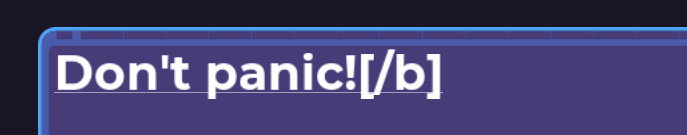

You can still nest tags though, if you want two effects at once:

```
bbcode_text = "[color=red][url]this is a red url[/url][/color]"
```

### How do I create hyperlinks with RichTextLabel?

You can use the BBCode `[url=$url]write your text here[/url]` where `$url` is your link *without quotes*.

For example you should write `[url=https://gdquest.com]...`, and **not** `[url="https://gdquest.com"]...` (notice the absence of quotes in the first example).

When the player clicks the text with the URL, the `RichTextLabel` emits the `meta_clicked` signal and passes the URL’s value. As such, you’re not limited to internet links: you can use `OS.shell_open()` to also support opening files and directories in the file explorer, and more.

```
onready var _label: RichTextLabel = $RichTextLabel

func _ready() -> void:
    # We enable and set the BBCode from code.
    _label.bbcode_enabled = true
    _label.bbcode_text = "[url=https://gdquest.com]GDQuest[/url]"

    # When the player clicks a url BBCode, we call `OS.shell_open()` with the
    # signal's argument.
    _label.connect("meta_clicked", OS, "shell_open")
```